# College Readiness Predictor, Place-level

Author

JP Walsh

Published

March 6, 2025

*Program for the creation of the College Readiness Upward Mobility Predictor at the place-level*

ACS Code: Initially written by Tina Chelidze and updated by JP Walsh 2022-2023.

Based on processes developed by Paul Johnson and Kevin Werner in SAS.

*User note* This program depends on extracts from the IPUMS ACS API interface. If you are updating the extract please remember to update the note of the date of latest extract in the Housekeeping section of this program.

*Internal users* If you are an internal tester using the AWS feature of this program remember to enter the passkey into your environment using Sys.setenv(). Authentication steps are nicely explained in this [blog](https://www.gormanalysis.com/blog/connecting-to-aws-s3-with-r/). You will have to request access to the access key.

*User warning* The ACS micro data used to create this metric is large and will take time to read in. It is strongly recommended that you use a server with significant computing power to run this.

## Housekeeping

Read in packages for use. If you do not have an IPUMS API key you will need to make one via the [IPUMS website](https://www.ipums.org/).

```r
library(tidyverse)
library(Hmisc)
library(ipumsr)
library(reactable)
library(srvyr)
library(scales)

options(scipen = 999)

# DO NOT PUSH YOUR API KEY. You only have to run this once and then comment it out as below.
#set_ipums_api_key("Your KEY", save = TRUE)

s3_dir <- "metric_name/data/acs"
my_bucket <- "mobility-from-poverty-test"

source(here::here("functions", "API", "extract_ipums_aws.R"))
source(here::here("functions", "API", "ipums_repwt_college_aws.R"))
source(here::here("functions", "testing", "evaluate_final_data.R"))
source(here::here("08_education", "R", "finalize_metric_college.R"))
source(here::here("08_education", "R", "calc_survey_mean_college.R"))
source(here::here("08_education", "R", "calc_survey_mean_subgroup_college.R"))
```

For internal reviewers, if you plan to utilize AWS keep this date as it was last enetered by the metric lead unless you intend to change the extract.

```r
ipums_extract_date <- "02_28_25"
ipums_repwt_extract_date <- "03_06_25"
```

If this is to update a single year of new data please set single_year_update to “Yes”. If not, set it to “No”.

```r
single_year_update = "No"
```

Define existing intermediate years and read them into function to combine.

```r
existing_years <- c("2014", "2016", "2018", "2021", "2023")
```

## Read Data

Read in the ACS extracts using the `extract_ipums()` function. Make sure to change the survey list to reflect what years you want to include in the data. The surveys being used in the code are defined in the code chunk below. For a list of available ACS surveys and their titles via the IPUMSR package you can run the following function: get_sample_info(“acs”).

```r
acs_surveys <- list(paste0("us", params$year, "c"))
```

Run extract. This will trigger an import process through IPUMS. It is encouraged to add detail to your extract description so it is clear what the extract was used for.

Date of latest extract noted above. If a new IPUMS pull is required the extract_date argument below must be updated to track that new data was downloaded. The extract only needs to be updated if changes or additions are required from the IPUMS pull (such as new dates or variables).

*Note this download is slow and will take some time to finish. The notes on “Checking extract status” are a feature of the IPUMSR package and are to be expected*

```r
acs <- extract_ipums_aws(
  extract_name = paste0("umf_data_", params$year, "_5year_acs"),
    extract_date = ipums_extract_date,
  extract_description = paste0("Microdata pull for College Readiness Metric Predictors. American Community Survey", params$year, "(5-year)."),
    survey = acs_surveys)
```

Look at the distribution of ACS survey samples in the data. The number of different samples should align with the number of surveys selected in the extract ipums function.

```r
count(acs, sample)
```

```
# A tibble: 1 x 2
  sample                       n
  <fct>                    <int>
1 2019-2023, ACS 5-year 15912393
```

Isolate the data to 19 and 20 year-olds. This is the age-range included in the college readiness calculation.

```r
acs <- acs %>%
  filter(age == 19 | age == 20)
```

### Replicate Weights

Read in person-level replicate weights for the 19 and 20 year old population. These will be used in creating standard errors for the college ready calculation.

Date of latest extract listed above. If a new IPUMS pull is required the extract_date argument below must be updated to track that new data was downloaded. The extract only needs to be updated if changes or additions are required from the IPUMS pull (such as new dates or variables).

```r
repwts_person <- ipums_repwt_college_aws(
  extract_name = paste0("college_replicate_weights_", params$year),
  extract_date = ipums_repwt_extract_date,
  extract_description = paste0("Person replicate weights for College Readiness Metric Predictors. American Community Survey,", params$year, "(5-year)."),
    survey = acs_surveys
)  %>%
  select(-cbserial, -cbpernum)
```

Look at the distribution of ACS survey samples in the data. The number of different samples should align with the number of surveys selected in the extract ipums function.

```r
count(repwts_person, sample)
```

```
# A tibble: 1 x 2
  sample                     n
  <fct>                  <int>
1 2019-2023, ACS 5-year 424048
```

Remove the sample variable.

```r
repwts_person <- repwts_person %>%
  select(-sample)
```

### Merge on repwts

```r
length(unique(pull(acs, unique_person_id)))
```

```
[1] 424048
```

```r
length(unique(pull(repwts_person, unique_person_id)))
```

```
[1] 424048
```

```r
acs_combined <-
  left_join(
    acs,
    repwts_person,
    by = "unique_person_id"
  )
length(unique(pull(acs_combined, unique_person_id)))
```

```
[1] 424048
```

```r
rm(acs)
rm(repwts_person)
```

Check that the merge did not result in any missing values.

```r
stopifnot(all(map_dbl(acs_combined, ~sum(is.na(.x))) == 0))
```

## Clean Data

Missing data is reported in a variety of ways by IPUMS data. This step walks through the missing values in key variables and checks that we are dealing with them appropriately.

Age: No missing values reported in variable description. Check the distribution to confirm there are no abnormalities: the distribution of age looks reasonable (no bunching or extreme outliers).

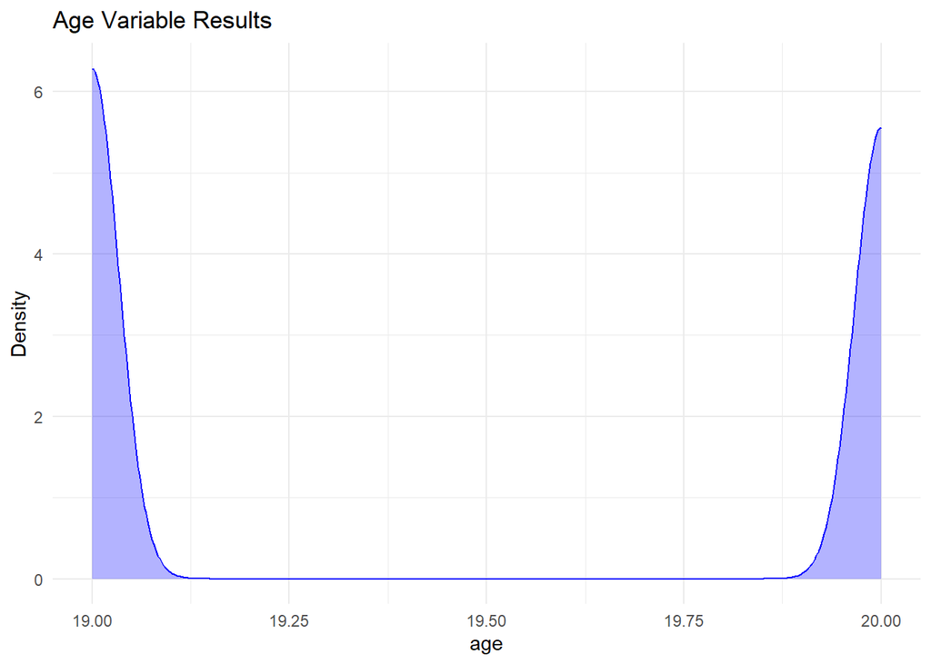

```r
acs_combined %>%
  ggplot(aes(x = age)) +
  geom_density(color = "blue", fill = alpha("blue", 0.3)) +
  theme_minimal() +
  ggtitle("Age Variable Results") +
  ylab("Density")
```

EDUCD: N/As reported as “1” in all modern surveys. N/As were “000” in the 1980 and 1950 decennial census surveys (not used here). Variable codes explained here & see “Detailed codes” at bottom). Vacancy is reported as “0”.

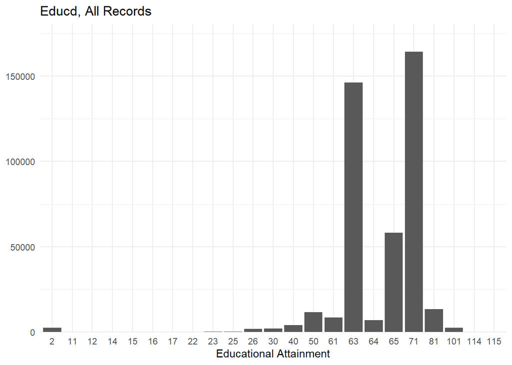

```r
acs_combined %>%
  mutate(educd = zap_labels(educd)) %>%
  count(educd) %>%
  ggplot(mapping = aes(x = factor(educd), y = n)) +
  geom_col() +
  theme_minimal() +
  ggtitle("Educd, All Records") +
  scale_y_continuous(expand = expansion(mult = c(0, 0.1))) +
  labs(x = "Educational Attainment",
       y = NULL)
```

Confirm the missing values from the value labels of the educd variable to ensure we are eliminating the correct values. “0”, “1” and “999” are N/A or missing and should be turned into NA values that R recognizes.

Note that there are no records with values of zero in the bar chart above which eliminates the need to deal with the “no schooling” option.

```r
head(ipums_val_labels(acs_combined$educd), 50) %>%
  reactable()
```

| val | lbl |
| --- | --- |
| 0 | N/A or no schooling |
| 1 | N/A |
| 2 | No schooling completed |
| 10 | Nursery school to grade 4 |
| 11 | Nursery school, preschool |
| 12 | Kindergarten |
| 13 | Grade 1, 2, 3, or 4 |
| 14 | Grade 1 |
| 15 | Grade 2 |
| 16 | Grade 3 |

[output cut: 34 more lines]

Turn the missing/“not in universe” value from the educd variable into NAs and remove the labels for the rest of the analysis. Rename to the more meaningful “education_detailed”.

```r
acs_clean <- acs_combined %>%
  mutate(education_detailed = zap_labels(educd),
         education_detailed = ifelse(education_detailed %in% c(1, 0, 999), NA_integer_,
                          education_detailed)
  )
```

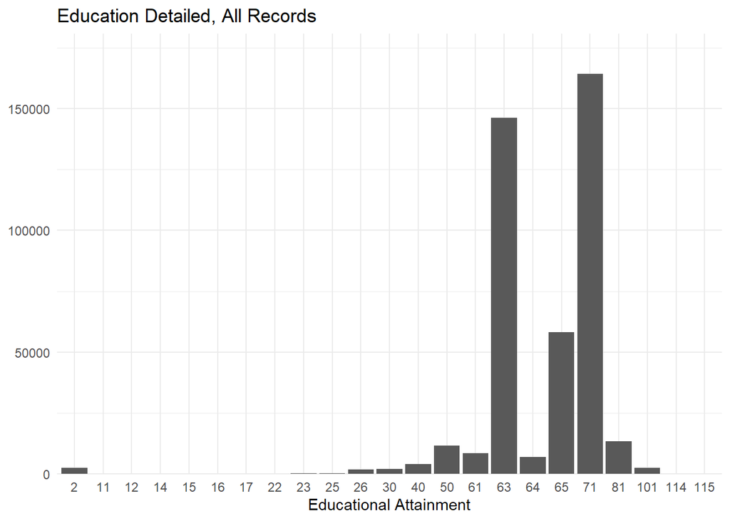

```r
acs_clean %>%
  count(education_detailed) %>%
  ggplot(mapping = aes(x = factor(education_detailed), y = n)) +
  geom_col() +
  theme_minimal() +
  ggtitle("Education Detailed, All Records") +
  scale_y_continuous(expand = expansion(mult = c(0, 0.1))) +
  labs(x = "Educational Attainment",
       y = NULL)
```

Vacancy: Value is reported as “0” according to IPUMs. Note there are no vacancy results by default of the structure of census data read in (confirmed in the distribution of the variable).

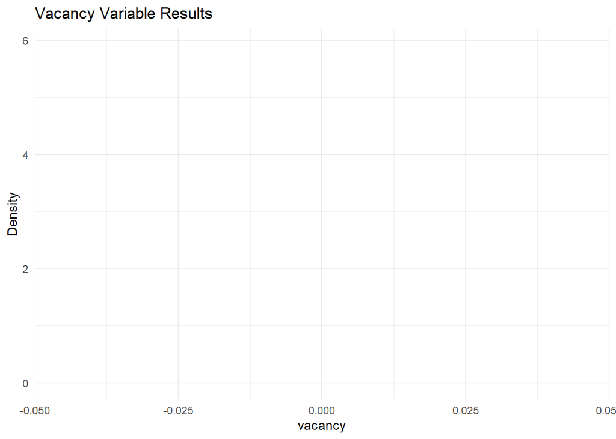

```r
acs_clean %>%
  ggplot(aes(x = vacancy)) +
  geom_density(color = "blue", fill = alpha("blue", 0.3)) +
  theme_minimal() +
  ggtitle("Vacancy Variable Results") +
  ylab("Density")
```

Examine the group quarters variable, we want to include both households and Group Quarters in this metric as both are relevant to the college readiness of a geography.

IPUMS includes the following categories:

- 0: Vacancy
- 1: Households under 1970 definition
- 2: Additional households under 1990 definition
- 3: Institutions
- 4: Other group quarters
- 5: Additional households under 2000 definition
- 6: Fragments

Check the distribution of GQ categories. Only households and group quarters should be included (no vacancy or fragments).

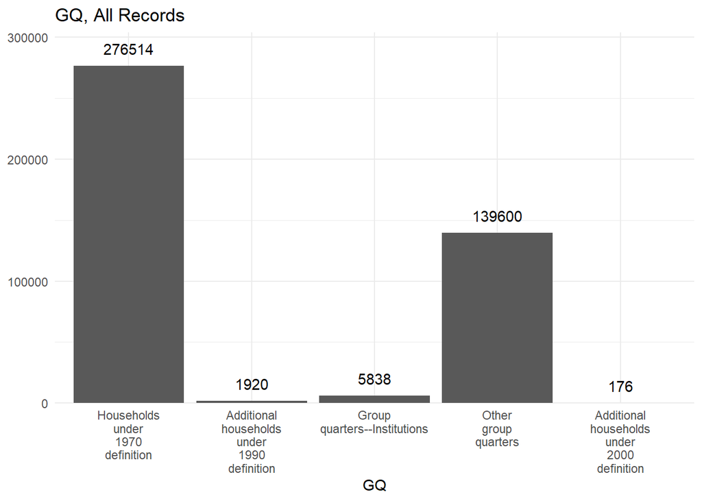

```r
acs_clean %>%
  count(gq) %>%
  ggplot(mapping = aes(x = gq, y = n)) +
  geom_col() +
  theme_minimal() +
  ggtitle("GQ, All Records") +
 geom_text(mapping = aes(label = n), vjust = -1) +
  scale_y_continuous(expand = expansion(mult = c(0, 0.1))) +
  labs(x = "GQ",
       y = NULL)+
  scale_x_discrete(labels = label_wrap(10))
```

### Create race variable

Evaluate the values in the RACE and HISPAN variables.

- IPUMS documented values for RACE:
  - 1 White
  - 2 Black/African American/Negro
  - 3 American Indian or Alaska Native
  - 4 Chinese
  - 5 Japanese
  - 6 Other Asian or Pacific Islander
  - 7 Other race
  - 8 Two major races
  - 9 Three or more major races
- IPUMS documented values for HISPAN:
  - 0 Not Hispanic
  - 1 Mexican
  - 2 Puerto Rican
  - 3 Cuban
  - 4 Other
  - 9 Not Reported

Look at the distribution of values for the race and hispan variables.

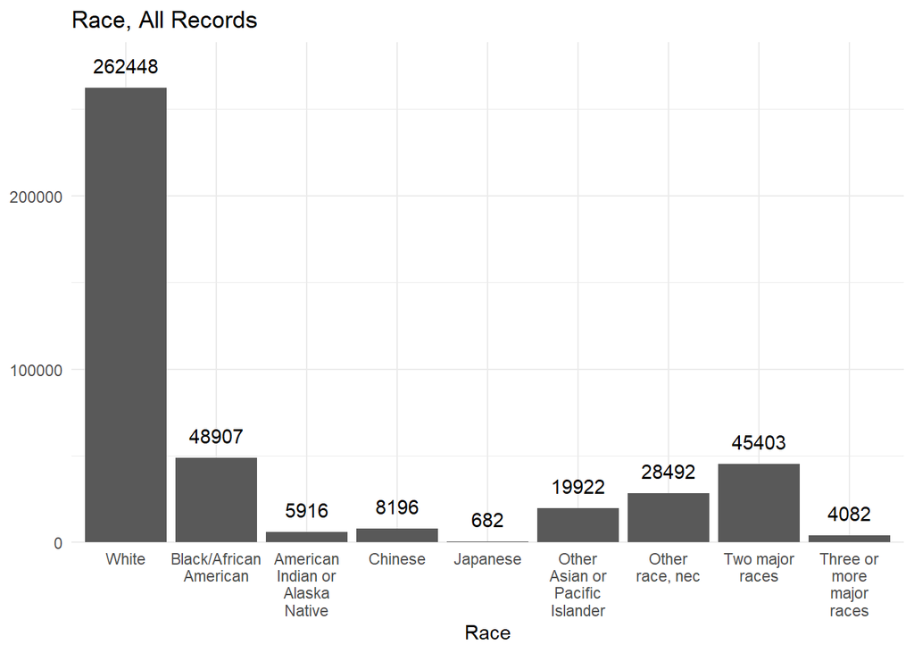

```r
acs_clean %>%
  count(race) %>%
  ggplot(mapping = aes(x = race, y = n)) +
  geom_col() +
  theme_minimal() +
  ggtitle("Race, All Records") +
 geom_text(mapping = aes(label = n), vjust = -1) +
  scale_y_continuous(expand = expansion(mult = c(0, 0.1))) +
  labs(x = "Race",
       y = NULL)+
  scale_x_discrete(labels = label_wrap(10))
```

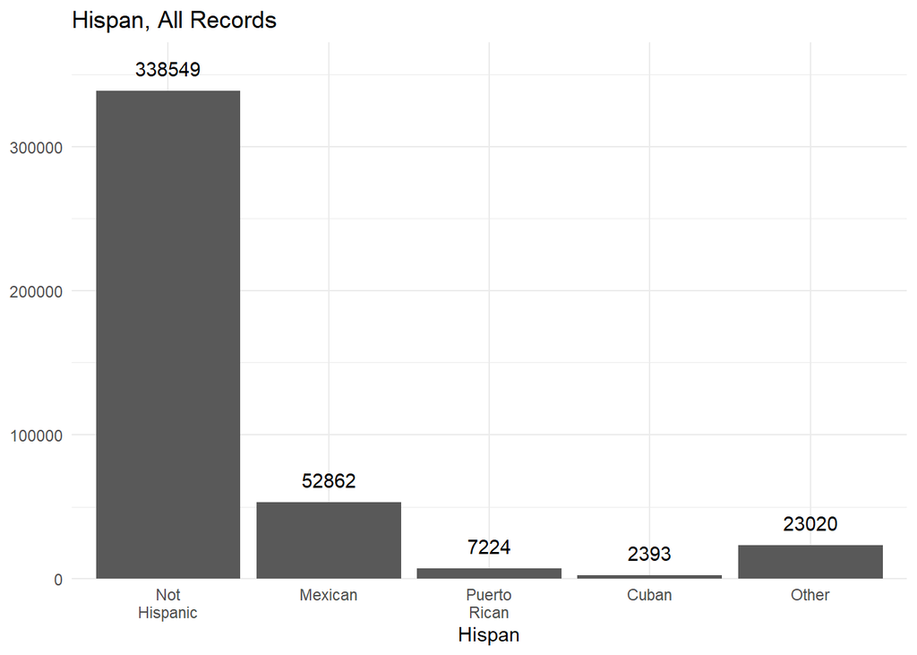

```r
acs_clean %>%
  count(hispan) %>%
  ggplot(mapping = aes(x = hispan, y = n)) +
  geom_col() +
  theme_minimal() +
  ggtitle("Hispan, All Records") +
 geom_text(mapping = aes(label = n), vjust = -1) +
  scale_y_continuous(expand = expansion(mult = c(0, 0.1))) +
  labs(x = "Hispan",
       y = NULL)+
  scale_x_discrete(labels = label_wrap(10))
```

Create the race/ethnicity variable. For race/ethnicity categories that are not coded as Hispanic, Hispan must be equal to “Not Hispanic”.

Rename the values from number category to race label: +Race is Black/African American and Hispan is Not Hispanic = “Black, Non-Hispanic” +Hispan is not equal to Not Hispanic = “Hispanic” +Race is not Black or White and Hispan is Not Hispanic = “Other Races and Ethnicities” +Race is White and Hispan is Not Hispanic = “White, Non-Hispanic”

```r
acs_clean <- acs_clean %>%
  mutate(subgroup_race = case_when((hispan == "Not Hispanic" & race == "White") ~ "White, Non-Hispanic",
                              (hispan == "Not Hispanic" & race == "Black/African American") ~ "Black, Non-Hispanic",
                              (hispan == "Not Hispanic" & !race %in% c("Black/African American", "White")) ~ "Other Races and Ethnicities",
                               hispan != "Not Hispanic" ~ "Hispanic"
  ))
```

Look at the race/ethnicity subgroup distribution.

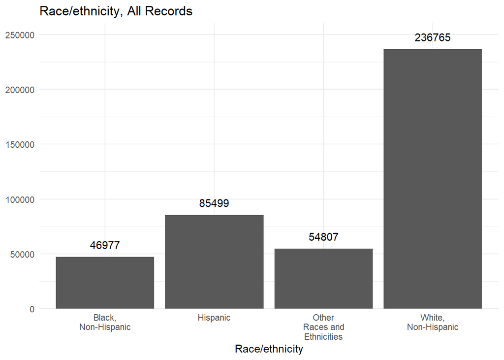

```r
acs_clean %>%
  count(subgroup_race) %>%
  ggplot(mapping = aes(x = factor(subgroup_race), y = n)) +
  geom_col() +
  theme_minimal() +
  ggtitle("Race/ethnicity, All Records") +
 geom_text(mapping = aes(label = n), vjust = -1) +
  scale_y_continuous(expand = expansion(mult = c(0, 0.1))) +
  labs(x = "Race/ethnicity",
       y = NULL)+
  scale_x_discrete(labels = label_wrap(10))
```

### Create gender variable

Evaluate the values in the gender variable.

- IPUMS documented values for SEX:
  - 1 Male
  - 2 Female
  - 9 Missing/blank

Look at the distribution of values for the sex variable. There are no missing values in the data and the records are reported in an appropriate format.

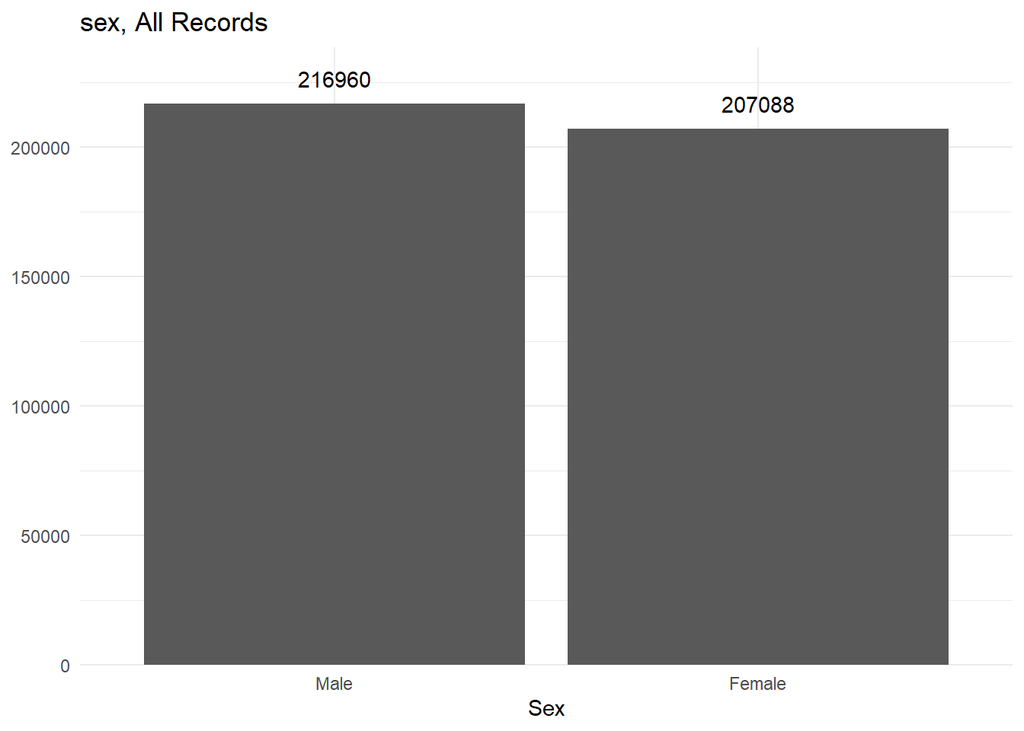

```r
acs_clean %>%
  count(sex) %>%
  ggplot(mapping = aes(x = sex, y = n)) +
  geom_col() +
  theme_minimal() +
  ggtitle("sex, All Records") +
 geom_text(mapping = aes(label = n), vjust = -1) +
  scale_y_continuous(expand = expansion(mult = c(0, 0.1))) +
  labs(x = "Sex",
       y = NULL)+
  scale_x_discrete(labels = label_wrap(10))
```

Rename the variable to subgroup_gender. The variable terms remain the same but any values outside of Male and Female are mutated to NA character variables. Though there are no missing values in the current data let’s leave this in the case of future ACS surveys including missing values for this variable.

```r
acs_clean <- acs_clean %>%
  mutate(subgroup_gender = case_when(sex == "Male" ~ "Male",
                                     sex == "Female" ~ "Female",
                                     TRUE ~ NA_character_))
```

### Create disability variable

The ACS includes 5 variables covering physical and mental disabilities (DIFFCARE, DIFFSENS, DIFFMOB, DIFFPHYS, DIFFREM). To make these variables more clear, first rename them.

```r
acs_clean <- acs_clean %>%
  rename(self_care_difficulty = diffcare,
         vision_hearing_difficulty = diffsens,
         independent_living_difficulty = diffmob,
         ambulatory_difficulty = diffphys,
         cognitive_difficulty = diffrem)
```

Evaluate the values in these variables and create an overall subgroup for disability. We will count an individual to be disabled if they answer yes or have any of these difficulties.

- IPUMS documented values for self_care_difficulty:
  - 0 N/A
  - 1 No
  - 2 Yes

Plot the options for self_care_difficulty below.

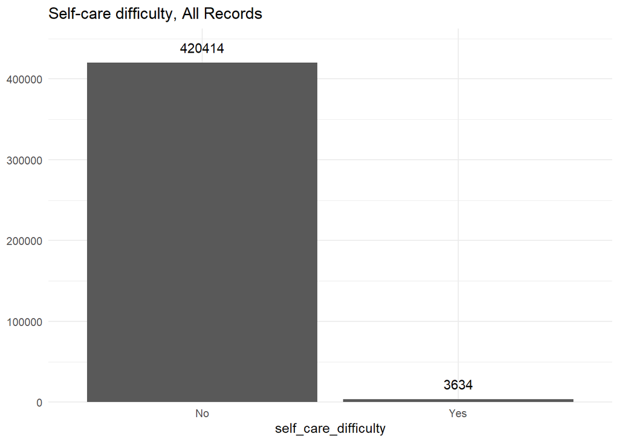

```r
acs_clean %>%
  count(self_care_difficulty) %>%
  ggplot(mapping = aes(x = self_care_difficulty, y = n)) +
  geom_col() +
  theme_minimal() +
  ggtitle("Self-care difficulty, All Records") +
 geom_text(mapping = aes(label = n), vjust = -1) +
  scale_y_continuous(expand = expansion(mult = c(0, 0.1))) +
  labs(x = "self_care_difficulty",
       y = NULL)+
  scale_x_discrete(labels = label_wrap(10))
```

- IPUMS documented values for vision_hearing_difficulty:
  - 0 N/A
  - 1 No vision or hearing difficulty
  - 2 Has vision or hearing difficulty

Plot the options for vision_hearing_difficulty below.

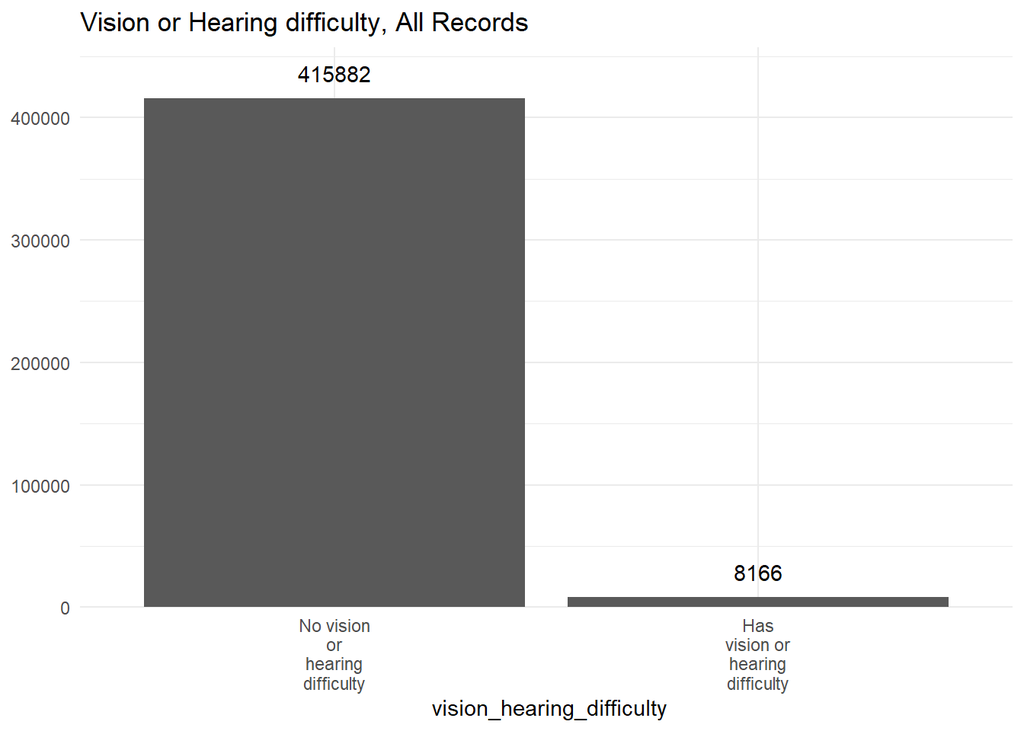

```r
acs_clean %>%
  count( vision_hearing_difficulty) %>%
  ggplot(mapping = aes(x =  vision_hearing_difficulty, y = n)) +
  geom_col() +
  theme_minimal() +
  ggtitle("Vision or Hearing difficulty, All Records") +
 geom_text(mapping = aes(label = n), vjust = -1) +
  scale_y_continuous(expand = expansion(mult = c(0, 0.1))) +
  labs(x = " vision_hearing_difficulty",
       y = NULL)+
  scale_x_discrete(labels = label_wrap(10))
```

- IPUMS documented values for independent_living_difficulty:
  - 0 N/A
  - 1 No independent living difficulty
  - 2 Has independent living difficulty

Plot the options for independent_living_difficulty below.

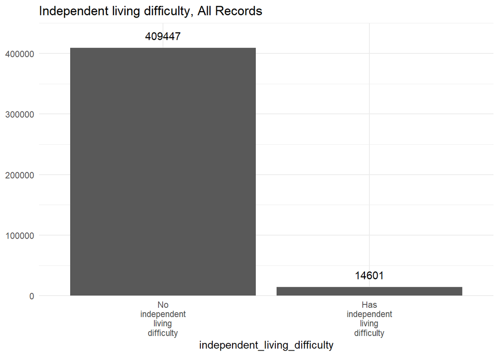

```r
acs_clean %>%
  count(independent_living_difficulty) %>%
  ggplot(mapping = aes(x = independent_living_difficulty, y = n)) +
  geom_col() +
  theme_minimal() +
  ggtitle("Independent living difficulty, All Records") +
 geom_text(mapping = aes(label = n), vjust = -1) +
  scale_y_continuous(expand = expansion(mult = c(0, 0.1))) +
  labs(x = "independent_living_difficulty",
       y = NULL)+
  scale_x_discrete(labels = label_wrap(10))
```

- IPUMS documented values for ambulatory_difficulty:
  - 0 N/A
  - 1 No ambulatory difficulty
  - 2 Has ambulatory difficulty

Plot the options for ambulatory_difficulty below.

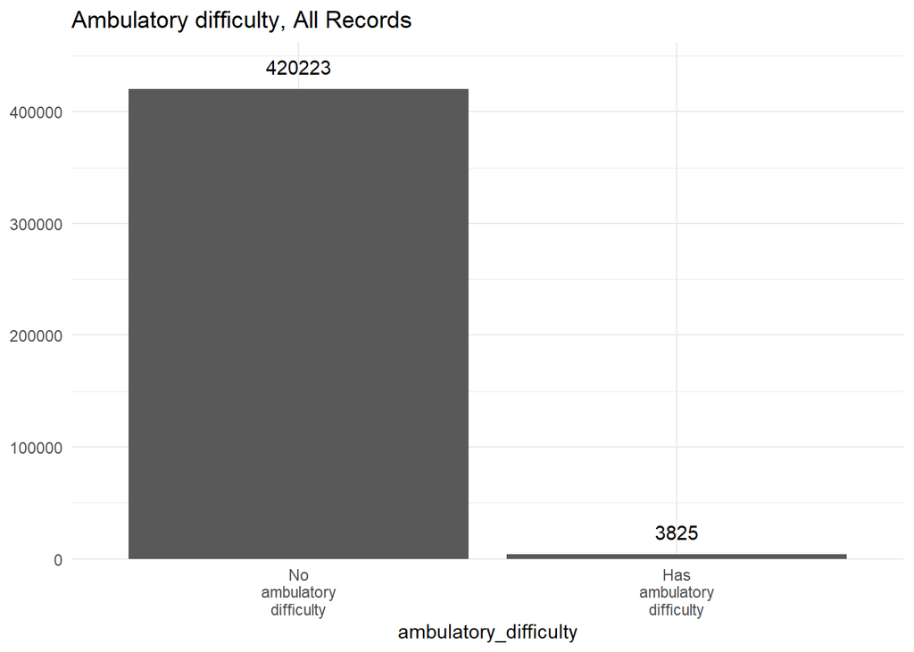

```r
acs_clean %>%
  count(ambulatory_difficulty) %>%
  ggplot(mapping = aes(x = ambulatory_difficulty, y = n)) +
  geom_col() +
  theme_minimal() +
  ggtitle("Ambulatory difficulty, All Records") +
 geom_text(mapping = aes(label = n), vjust = -1) +
  scale_y_continuous(expand = expansion(mult = c(0, 0.1))) +
  labs(x = "ambulatory_difficulty",
       y = NULL)+
  scale_x_discrete(labels = label_wrap(10))
```

- IPUMS documented values for cognitive_difficulty:
  - 0 N/A
  - 1 No cognitive difficulty
  - 2 Has cognitive difficulty

Plot the options for cognitive_difficulty below.

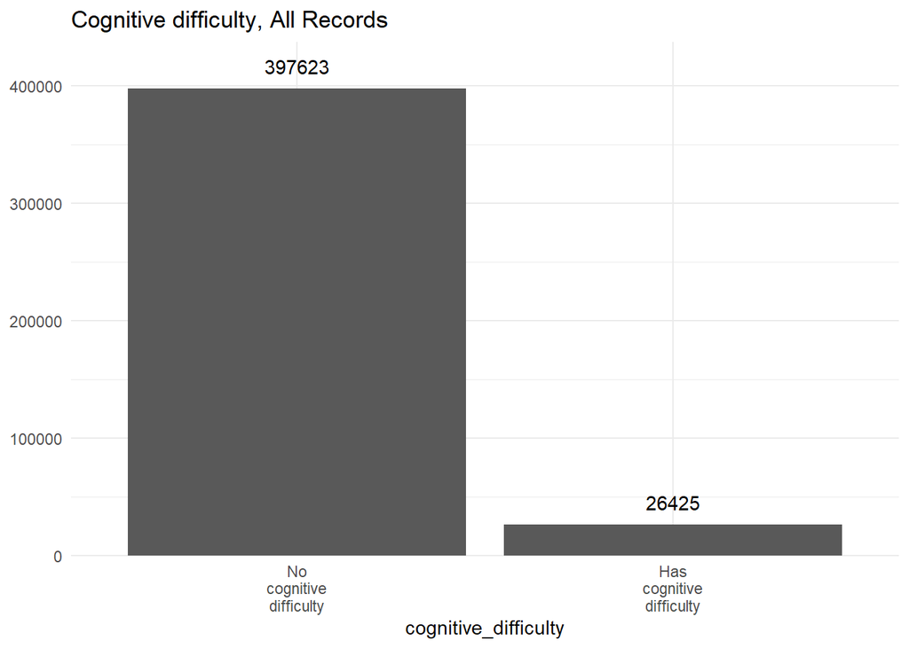

```r
acs_clean %>%
  count(cognitive_difficulty) %>%
  ggplot(mapping = aes(x = cognitive_difficulty, y = n)) +
  geom_col() +
  theme_minimal() +
  ggtitle("Cognitive difficulty, All Records") +
 geom_text(mapping = aes(label = n), vjust = -1) +
  scale_y_continuous(expand = expansion(mult = c(0, 0.1))) +
  labs(x = "cognitive_difficulty",
       y = NULL)+
  scale_x_discrete(labels = label_wrap(10))
```

Create the subgroup for disability.

```r
acs_clean <- acs_clean %>%
  mutate(subgroup_disability = case_when(cognitive_difficulty == "Has cognitive difficulty" |
                                           ambulatory_difficulty == "Has ambulatory difficulty" |
                                           independent_living_difficulty == "Has independent living difficulty" |
                                            vision_hearing_difficulty == "Has vision or hearing difficulty" |
                                           self_care_difficulty == "Yes" ~ "With Disability",
                                         TRUE ~ "Without Disability"))
```

Check the variable breakout.

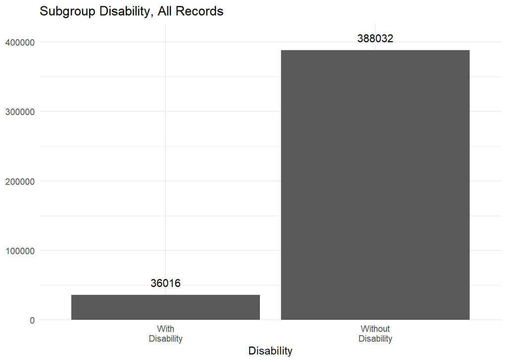

```r
acs_clean %>%
  count(subgroup_disability) %>%
  ggplot(mapping = aes(x = subgroup_disability, y = n)) +
  geom_col() +
  theme_minimal() +
  ggtitle("Subgroup Disability, All Records") +
 geom_text(mapping = aes(label = n), vjust = -1) +
  scale_y_continuous(expand = expansion(mult = c(0, 0.1))) +
  labs(x = "Disability",
       y = NULL)+
  scale_x_discrete(labels = label_wrap(10))
```

## Crosswalk

Read in the PUMA to place crosswalk file. This file is created by the program generate_puma_place_crosswalks.rmd in the geographic-crosswalks folder.

```r
puma_place_crosswalk <- read_csv(here::here("geographic-crosswalks", "data", "crosswalk_puma_to_place.csv"))
```

Create a version with just unique places for creating a version of the data that matches the UMF place list.

```r
place_list <- puma_place_crosswalk %>%
  select(statefip, place) %>%
  unique()
```

## Merge Crosswalk

Create a variable in the ACS data indicating whether the survey year is pre or post-2022. This will be used to join on the correct crosswalk information.

```r
acs_clean <- acs_clean %>%
  mutate(crosswalk_period = ifelse(year < 2022, "pre-2022", "2022"))
```

Check that the assignment worked. All years prior to 2022 should be designated “pre-2022”.

```r
acs_clean %>%
  group_by(crosswalk_period, year) %>%
  count()
```

```
# A tibble: 1 x 3
# Groups:   crosswalk_period, year [1]
  crosswalk_period  year      n
  <chr>            <int>  <int>
1 2022              2023 424048
```

Join the cleaned ACS data onto the crosswalk.

```r
acs_crosswalked <- left_join(
  acs_clean,
  puma_place_crosswalk,
  by=c("crosswalk_period", "statefip","puma"),
  relationship = "many-to-many"
)
```

Drop any observations with NA for afact (i.e. there is no place of interest overlapping this PUMA).

```r
acs_crosswalked <- acs_crosswalked %>%
  drop_na(afact)
```

Also filter out cases where AFACT is equal to zero. These cases will not be counted in the metric calculation.

```r
acs_crosswalked <- acs_crosswalked %>%
  filter(afact > 0)
```

Adjust the person weight to account for PUMA-to-place mapping (those where the PUMA is not entirely inside the place).

```r
select(acs_crosswalked, perwt, repwtp1, repwtp80, afact)
```

```
# A tibble: 253,803 x 4
   perwt repwtp1 repwtp80  afact
   <dbl>   <dbl>    <dbl>  <dbl>
 1    20      36       39 0.514
 2     1       1        2 0.0531
 3     1       1        2 0.284
 4    19      19        1 0.887
 5    16      31       15 0.837
 6    19      20        2 0.514
 7    19      20       35 0.0531
 8    19      20       35 0.284
 9    18      18       18 0.752
10    16      31       33 0.514
# i 253,793 more rows
```

```r
acs_crosswalked <- acs_crosswalked %>%
  mutate(perwt = perwt * afact) %>%
  mutate(across(matches("repwtp[0-9]+"), ~.x * afact))
select(acs_crosswalked, perwt, repwtp1, repwtp80, afact)
```

```
# A tibble: 253,803 x 4
     perwt repwtp1 repwtp80  afact
     <dbl>   <dbl>    <dbl>  <dbl>
 1 10.3    18.5      20.0   0.514
 2  0.0531  0.0531    0.106 0.0531
 3  0.284   0.284     0.568 0.284
 4 16.9    16.9       0.887 0.887
 5 13.4    25.9      12.6   0.837
 6  9.76   10.3       1.03  0.514
 7  1.01    1.06      1.86  0.0531
 8  5.40    5.68      9.95  0.284
 9 13.5    13.5      13.5   0.752
10  8.22   15.9      17.0   0.514
# i 253,793 more rows
```

## Prepare comuptational variables

Create a binary college_ready variable indicating whether the individual has a HS degree or not (including GED as HS degree equivalent). IPUMS codes HS graduate or GED (62) and above are all considered to meet this requirement.

```r
acs_crosswalked <- acs_crosswalked %>%
  mutate(college_ready = ifelse(education_detailed >= 62, 1, 0))
```

Check how many records, if any, have NA reported for education_detailed after filtering (this should be zero).

```r
acs_crosswalked %>%
  filter(is.na(education_detailed)) %>%
  group_by(pernum) %>%
  count()
```

```
# A tibble: 0 x 2
# Groups:   pernum [0]
# i 2 variables: pernum <dbl>, n <int>
```

Check the distribution of the education_detailed variable one last time - there should be no NA values included.

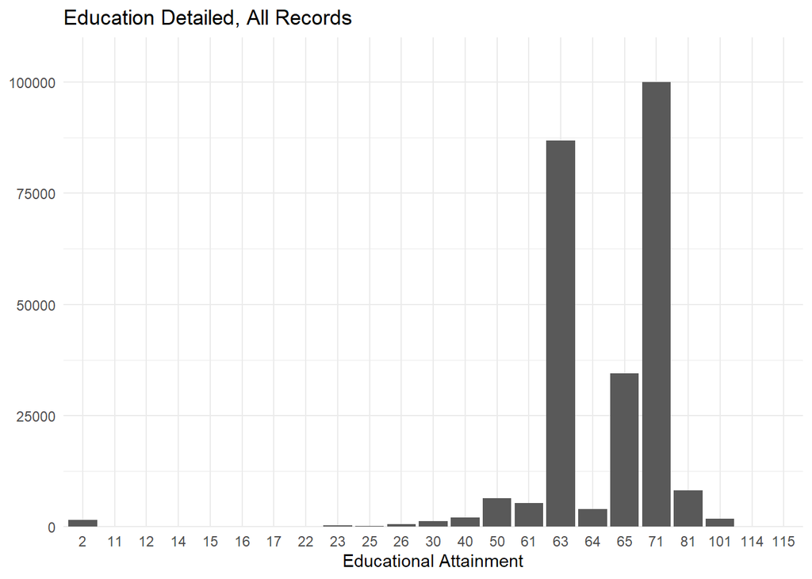

```r
acs_crosswalked %>%
  count(education_detailed) %>%
  ggplot(mapping = aes(x = factor(education_detailed), y = n)) +
  geom_col() +
  theme_minimal() +
  ggtitle("Education Detailed, All Records") +
  scale_y_continuous(expand = expansion(mult = c(0, 0.1))) +
  labs(x = "Educational Attainment",
       y = NULL)
```

Confirm there are no vacant properties included in the data.

```r
acs_crosswalked %>%
  filter(is.na(vacancy)) %>%
  group_by(pernum) %>%
  count()
```

```
# A tibble: 0 x 2
# Groups:   pernum [0]
# i 2 variables: pernum <dbl>, n <int>
```

## Create college readiness metric: All

Create the college ready metric.

Objective: get the percent of individuals between 19 and 20 that have a HS degree.

Aggregation should be weighted by PERWT (this is a person level statistic).

### Pre-drop suppressed cells

First, to save time when processing the metric, calculate the effective sample count for each place, defined as the sum of the `afact` variable. This is used to create a cutoff for data quality based on the actual number of survey records being used in the calculation. We will not include counties with less than 30 effective samples.

```r
acs_all <- acs_crosswalked %>%
  group_by(year, sample, crosswalk_period, statefip, place) %>%
  mutate(effective_sample = sum(afact)) %>%
  ungroup()
# calculate the number of statistics after suppressing values
acs_all %>%
  group_by(year, sample, crosswalk_period, statefip, place) %>%
  summarise(
    effective_sample = max(effective_sample)
  ) %>%
  ungroup() %>%
  summarise(
    original_stats = n(),
    unsuppressed_stats = sum(effective_sample >= 30)
  )
```

```
# A tibble: 1 x 2
  original_stats unsuppressed_stats
           <int>              <int>
1            486                486
```

Remove records from counties below the size quality cutoff.

```r
acs_all <- acs_all %>%
  filter(effective_sample >= 30)
```

### Calculate metric

Calculate the place-level metrics.

```r
results_all <- acs_all %>%
  group_split(statefip) %>%
  map_dfr(~ calc_survey_mean_college(.data = .x, .geo_level = place))
```

Clean up the confidence interval bounds and sort the data.

```r
results_all <- finalize_metric_college(results_all)
```

```r
rm(acs_all)
```

## Add Suppressed Rows to Data

To create the metric we suppressed counties that did not meet the threshold for sample size but we need to include these in the final data. Create an all version of the data from the place_list file that includes counties that were suppressed prior to the survey_mean calculation.

Expand the place_list file so it includes every year in the results. Join the results onto this file and test that the number of records is what we anticipate.

```r
expanded_place_list <- place_list %>%
  left_join(results_all, by = c("statefip", "place"), relationship = "many-to-many") %>%
  mutate(geoid = paste0(statefip, place)) %>%
  expand(year, geoid) %>%
  mutate(statefip = str_sub(geoid, 1, 2),
         place = str_sub(geoid, 3, 7))

results_all_expand <- expanded_place_list %>%
  left_join(results_all, by = c("year", "statefip", "place")) %>%
  filter(!is.na(year))

stopifnot(nrow(results_all_expand) == 486 * n_distinct(results_all_expand$year))
```

## Data Quality Flags

Add a flag for data quality, this is a numeric variable between 1 and 3 with 1 representing the best quality and 3 representing the worst.

```r
metrics_education_all <- results_all_expand %>%
  mutate(
    share_hs_degree_quality = if_else(
      is.na(share_hs_degree),
      NA_real_,
      geographic_allocation_quality
    )
  )
```

### Write out intermediate data

```r
if(isTRUE(bucket_exists(bucket = my_bucket))){
 if (!aws.s3::object_exists(paste0(s3_dir, "/metrics_college_all", "_", params$year[1], ".csv"), bucket = my_bucket)){

    # write file to S3
    tmp <- tempfile()
    on.exit(unlink(tmp))
    write_csv(metrics_education_all, file = tmp)

    # put object with an upload progress bar
    put_object(tmp, object = paste0(s3_dir, "/metrics_college_all", "_", params$year, ".csv"), bucket = my_bucket,
               show_progress = TRUE, multipart = FALSE)

  }
}
```

```
[1] TRUE
```

## Create college metric: subgroups

## Race/Ethnicity

To save time when processing the metric, calculate the effective sample count for each race-ethnicity group in each place, defined as the sum of the `afact` variable. This is used to create a cutoff for data quality based on the actual number of survey records being used in the calculation. We will not include counties with less than 30 effective samples.

```r
acs_race_ethnicity <- acs_crosswalked %>%
  group_by(year, sample, crosswalk_period, statefip, place, subgroup_race) %>%
  mutate(effective_sample = sum(afact)) %>%
  ungroup()
# calculate the number of statistics after suppressing values
acs_race_ethnicity %>%
  group_by(year, sample, crosswalk_period, statefip, place, subgroup_race) %>%
  summarise(
    effective_sample = max(effective_sample)
  ) %>%
  ungroup() %>%
  summarise(
    original_stats = n(),
    unsuppressed_stats = sum(effective_sample >= 30)
  )
```

```
# A tibble: 1 x 2
  original_stats unsuppressed_stats
           <int>              <int>
1           1938                962
```

Create the college readiness metric for the race/ethnicity subgroup.

Remove records from counties below the size quality cutoff.

```r
acs_race_ethnicity <- acs_race_ethnicity %>%
  filter(effective_sample >= 30)
```

### Calculate metric

```r
results_race_ethnicity <- acs_race_ethnicity %>%
  group_split(statefip) %>%
  map_dfr(~ calc_survey_mean_subgroup_college(.data = .x,
                                      .geo_level = place,
                                      .subgroup = subgroup_race))
```

```r
results_race_ethnicity <- finalize_metric_college(results_race_ethnicity)
```

```r
rm(acs_race_ethnicity)
```

### Add Suppressed Rows to Data

To create the metric we suppressed counties that did not meet the threshold for sample size but we need to include these in the final data. Create an all version of the data that includes counties that were suppressed prior to the survey_mean calculation.

Create expanded version for race-ethnicity.

```r
expanded_place_list_race <- place_list %>%
  left_join(results_race_ethnicity, by = c("statefip", "place"), relationship = "many-to-many") %>%
  mutate(geoid = paste0(statefip, place)) %>%
  expand(year, geoid, subgroup_race) %>%
  mutate(statefip = str_sub(geoid, 1, 2),
         place = str_sub(geoid, 3, 7))

results_race_ethnicity_expanded <- expanded_place_list_race  %>%
  left_join(results_race_ethnicity, by = c("year", "statefip", "place", "subgroup_race")) %>%
  filter(!is.na(year), !is.na(subgroup_race)) %>%
  mutate(subgroup_type = "race-ethnicity") %>%
  rename(subgroup = subgroup_race)

stopifnot(nrow(results_race_ethnicity_expanded) == 486 * n_distinct(results_all_expand$year) * 4)
```

## Gender

To save time when processing the metric, calculate the effective sample count for each gender group in each place, defined as the sum of the `afact` variable. This is used to create a cutoff for data quality based on the actual number of survey records being used in the calculation. We will not include counties with less than 30 effective samples.

```r
acs_gender <- acs_crosswalked %>%
  group_by(year, sample, crosswalk_period, statefip, place, subgroup_gender) %>%
  mutate(effective_sample = sum(afact)) %>%
  ungroup()
# calculate the number of statistics after suppressing values
acs_gender %>%
  group_by(year, sample, crosswalk_period, statefip, place, subgroup_gender) %>%
  summarise(
    effective_sample = max(effective_sample)
  ) %>%
  ungroup() %>%
  summarise(
    original_stats = n(),
    unsuppressed_stats = sum(effective_sample >= 30)
  )
```

```
# A tibble: 1 x 2
  original_stats unsuppressed_stats
           <int>              <int>
1            972                893
```

Create the college readiness metric for the gender subgroup.

Remove records from counties below the size quality cutoff.

```r
acs_gender <- acs_gender %>%
  filter(effective_sample >= 30)
```

### Calculate metric

```r
results_gender <- acs_gender %>%
  group_split(statefip) %>%
  map_dfr(~ calc_survey_mean_subgroup_college(.data = .x,
                                      .geo_level = place,
                                      .subgroup = subgroup_gender))
```

```r
results_gender <- finalize_metric_college(results_gender)
```

```r
rm(acs_gender)
```

### Add Suppressed Rows to Data

To create the metric we suppressed counties that did not meet the threshold for sample size but we need to include these in the final data. Create an all version of the data that includes counties that were suppressed prior to the survey_mean calculation.

Create expanded version for gender data and test that the number of records are accurate.

```r
expanded_place_list_gender <- place_list %>%
  left_join(results_gender, by = c("statefip", "place"), relationship = "many-to-many") %>%
  mutate(geoid = paste0(statefip, place)) %>%
  expand(year, geoid, subgroup_gender) %>%
  mutate(statefip = str_sub(geoid, 1, 2),
         place = str_sub(geoid, 3, 7))

results_gender_expanded <- expanded_place_list_gender  %>%
  left_join(results_gender, by = c("year", "statefip", "place", "subgroup_gender")) %>%
  filter(!is.na(year), !is.na(subgroup_gender)) %>%
  mutate(subgroup_type = "gender") %>%
  rename(subgroup = subgroup_gender)

stopifnot(nrow(results_gender_expanded) == 486 * n_distinct(results_all_expand$year) * 2)
```

## Disability

To save time when processing the metric, calculate the effective sample count for each disability group in each place, defined as the sum of the `afact` variable. This is used to create a cutoff for data quality based on the actual number of survey records being used in the calculation. We will not include counties with less than 30 effective samples.

```r
acs_disability <- acs_crosswalked %>%
  group_by(year, sample, crosswalk_period, statefip, place, subgroup_disability) %>%
  mutate(effective_sample = sum(afact)) %>%
  ungroup()
# calculate the number of statistics after suppressing values
acs_disability %>%
  group_by(year, sample, crosswalk_period, statefip, place, subgroup_disability) %>%
  summarise(
    effective_sample = max(effective_sample)
  ) %>%
  ungroup() %>%
  summarise(
    original_stats = n(),
    unsuppressed_stats = sum(effective_sample >= 30)
  )
```

```
# A tibble: 1 x 2
  original_stats unsuppressed_stats
           <int>              <int>
1            972                590
```

Create the college readiness metric for the disability subgroup.

Remove records from counties below the size quality cutoff.

```r
acs_disability <- acs_disability %>%
  filter(effective_sample >= 30)
```

### Calculate metric

```r
results_disability <- acs_disability %>%
  group_split(statefip) %>%
  map_dfr(~ calc_survey_mean_subgroup_college(.data = .x,
                                      .geo_level = place,
                                      .subgroup = subgroup_disability))
```

```r
results_disability <- finalize_metric_college(results_disability)
```

```r
rm(acs_disability)
```

### Add Suppressed Rows to Data

To create the metric we suppressed counties that did not meet the threshold for sample size but we need to include these in the final data. Create an all version of the data that includes counties that were suppressed prior to the survey_mean calculation.

Create expanded version for disability data.

```r
expanded_place_list_disability <- place_list %>%
  left_join(results_disability, by = c("statefip", "place"), relationship = "many-to-many") %>%
  mutate(geoid = paste0(statefip, place)) %>%
  expand(year, geoid, subgroup_disability) %>%
  mutate(statefip = str_sub(geoid, 1, 2),
         place = str_sub(geoid, 3, 7))

results_disability_expanded <- expanded_place_list_disability  %>%
  left_join(results_disability, by = c("year", "statefip", "place", "subgroup_disability")) %>%
  filter(!is.na(year), !is.na(subgroup_disability)) %>%
  mutate(subgroup_type = "disability") %>%
  rename(subgroup = subgroup_disability)

stopifnot(nrow(results_disability_expanded) == 486 * n_distinct(results_all_expand$year) * 2)
```

## Data Quality Flags

Add a flag for data quality, this is a numeric variable between 1 and 3 with 1 representing the best quality and 3 representing the worst.

First combine the subgroup data sets.

```r
metrics_education_sub <- results_all_expand %>%
  mutate(subgroup = "All",
         subgroup_type = "all") %>%
  bind_rows(results_race_ethnicity_expanded, results_disability_expanded, results_gender_expanded)
```

```r
metrics_education_sub <- metrics_education_sub %>%
  mutate(
    share_hs_degree_quality = if_else(
      is.na(share_hs_degree),
      NA_real_,
      geographic_allocation_quality
    )
  )
```

### Write out intermediate data

For internal users with AWS access - write out intermediate data.

```r
 if(isTRUE(bucket_exists(bucket = my_bucket))){
   if (!aws.s3::object_exists(paste0(s3_dir, "/metrics_college_sub", "_", params$year, ".csv"), bucket = my_bucket)){

    # write file to S3
    tmp <- tempfile()
    on.exit(unlink(tmp))
    write_csv(metrics_education_sub, file = tmp)

    # put object with an upload progress bar
    put_object(tmp, object = paste0(s3_dir, "/metrics_college_sub", "_", params$year, ".csv"), bucket = my_bucket,
               show_progress = TRUE, multipart = FALSE)

   }
 }
```

```
[1] TRUE
```

If updating a single year the program ends here. To see validation results re-run with selection that all years of intermediate data are available.

```r
if(single_year_update == "Yes"){
  knitr::knit_exit()
}
```

## Result Validation

Validate results for all years of available output.

### Read intermediate files

Read in the intermediate files created for each ACS year available.

Function reads the CSVs from intermediate folder or from AWS if the user has access.

```r
read_intermediate <- function(year, file_type){

  if(isTRUE(bucket_exists(bucket = my_bucket))) {

    s3read_using(FUN=read_csv,
                 bucket = my_bucket,
                 object=paste0(s3_dir, "/metrics_college_", file_type, "_", year, ".csv")) %>%
    mutate(crosswalk_period = as.character(crosswalk_period))

  }
  else{

  read_csv(paste0(here::here("08_education", "data", "intermediate", "college"),
                  "/", "metrics_college_", file_type, "_", year, ".csv"))
  }

}
```

```r
check <- get_bucket_df(bucket = my_bucket)
metrics_education_all <- map_df(.x = existing_years, .f = ~read_intermediate(year = .x,
                                                                          file_type = "all"))
metrics_education_sub <- map_df(.x = existing_years, .f = ~read_intermediate(year = .x,
                                                                          file_type = "sub"))
```

Create summary tables for the values from the results for both all and for subgroups.

```r
metrics_education_all %>%
  select(share_hs_degree:share_hs_degree_quality) %>%
  summary()
```

```
 share_hs_degree  geographic_allocation_quality share_hs_degree_lb
 Min.   :0.6328   Min.   :1.000                 Min.   :0.5043
 1st Qu.:0.8672   1st Qu.:1.000                 1st Qu.:0.8029
 Median :0.9046   Median :2.000                 Median :0.8558
 Mean   :0.8989   Mean   :1.941                 Mean   :0.8476
 3rd Qu.:0.9382   3rd Qu.:2.000                 3rd Qu.:0.8993
 Max.   :1.0000   Max.   :3.000                 Max.   :1.0000
 NA's   :21       NA's   :21                    NA's   :21
 share_hs_degree_ub share_hs_degree_quality
 Min.   :0.7614     Min.   :1.000
 1st Qu.:0.9267     1st Qu.:1.000
 Median :0.9573     Median :2.000
 Mean   :0.9497     Mean   :1.941
 3rd Qu.:0.9806     3rd Qu.:2.000
 Max.   :1.0000     Max.   :3.000
 NA's   :21         NA's   :21
```

```r
metrics_education_sub %>%
  filter(subgroup != "All") %>%
  select(share_hs_degree:share_hs_degree_quality) %>%
  summary()
```

```
 share_hs_degree geographic_allocation_quality share_hs_degree_lb
 Min.   :0.424   Min.   :1.000                 Min.   :0.172
 1st Qu.:0.862   1st Qu.:1.000                 1st Qu.:0.780
 Median :0.912   Median :2.000                 Median :0.850
 Mean   :0.899   Mean   :1.921                 Mean   :0.833
 3rd Qu.:0.951   3rd Qu.:2.000                 3rd Qu.:0.908
 Max.   :1.000   Max.   :3.000                 Max.   :1.000
 NA's   :7837    NA's   :7837                  NA's   :7837
 share_hs_degree_ub   subgroup         subgroup_type
 Min.   :0.567      Length:19440       Length:19440
 1st Qu.:0.941      Class :character   Class :character
 Median :0.977      Mode  :character   Mode  :character
 Mean   :0.961
 3rd Qu.:0.999
 Max.   :1.000
 NA's   :7837
 share_hs_degree_quality
 Min.   :1.000
 1st Qu.:1.000
 Median :2.000
 Mean   :1.921
 3rd Qu.:2.000
 Max.   :3.000
 NA's   :7837
```

Look at distribution of college readiness share by place for all and for subgroups.

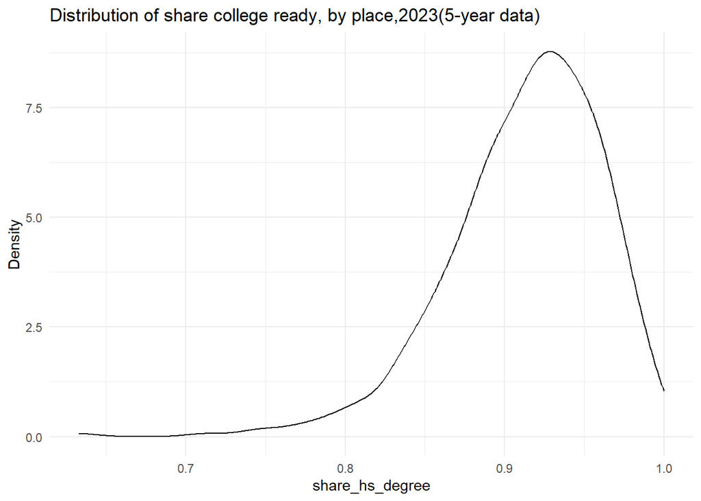

```r
metrics_education_all %>%
  filter(year == params$year) %>%
  select(share_hs_degree) %>%
  ggplot(aes(x = share_hs_degree)) +
  geom_density(alpha = 0.15) +
  theme_minimal() +
  ggtitle(paste0("Distribution of share college ready, by place,", params$year, "(5-year data)")) +
  ylab("Density")
```

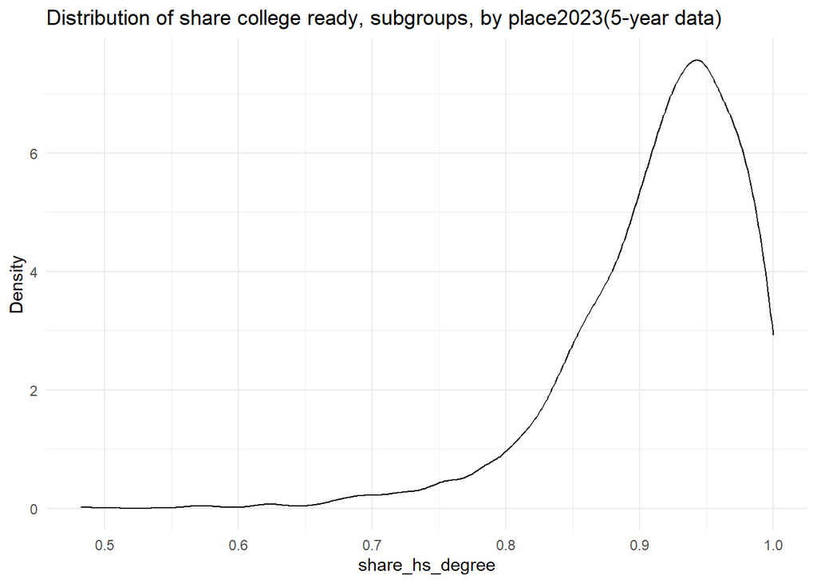

```r
metrics_education_sub %>%
  filter(year == params$year, subgroup != "All") %>%
  select(share_hs_degree) %>%
  ggplot(aes(x = share_hs_degree)) +
  geom_density(alpha = 0.15) +
  theme_minimal() +
  ggtitle(paste0("Distribution of share college ready, subgroups, by place", params$year, "(5-year data)")) +
  ylab("Density")
```

### Race/ethnicity

Look at distribution of college readiness share by place for each individual subgroup.

Race/ethnicity.

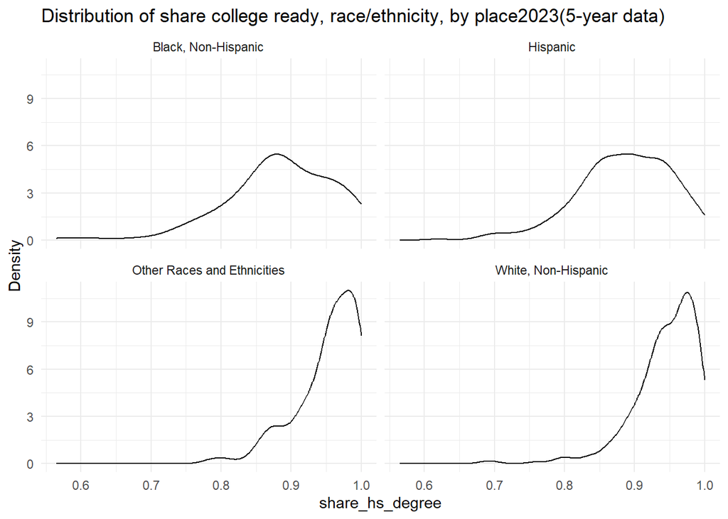

```r
metrics_education_sub %>%
  filter(year == params$year, subgroup_type == "race-ethnicity") %>%
  ggplot(aes(x = share_hs_degree)) +
  geom_density(alpha = 0.15) +
  facet_wrap(~subgroup) +
  labs(
    title = paste0("Distribution of share college ready, race/ethnicity, by place", params$year, "(5-year data)"),
    y = "Density"
  ) +
  theme_minimal()
```

### Gender

Gender.

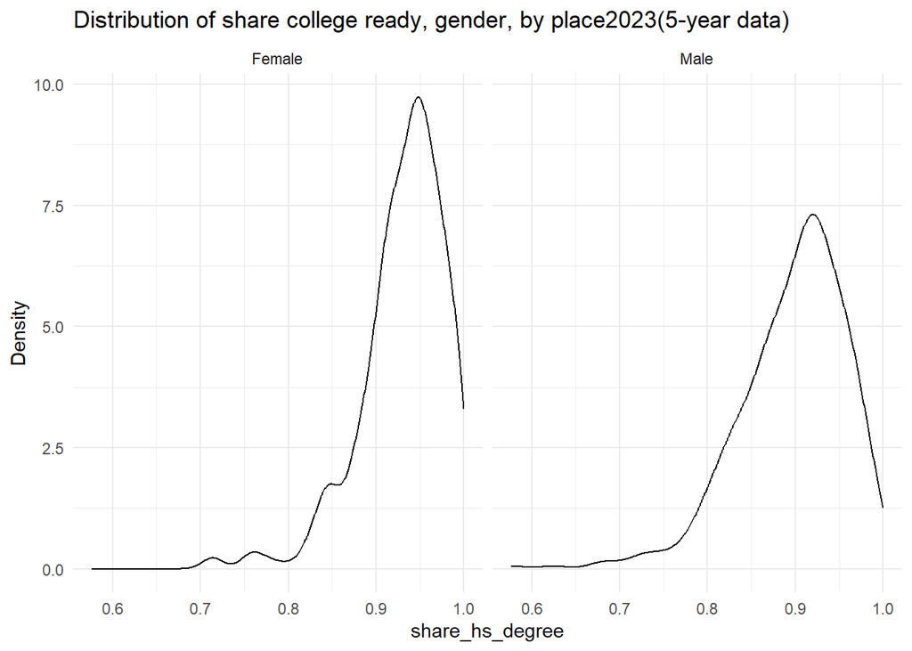

```r
metrics_education_sub %>%
  filter(year == params$year, subgroup_type == "gender") %>%
  ggplot(aes(x = share_hs_degree)) +
  geom_density(alpha = 0.15) +
  facet_wrap(~subgroup) +
  labs(
    title = paste0("Distribution of share college ready, gender, by place", params$year, "(5-year data)"),
    y = "Density"
  ) +
  theme_minimal()
```

### Disability

Disability.

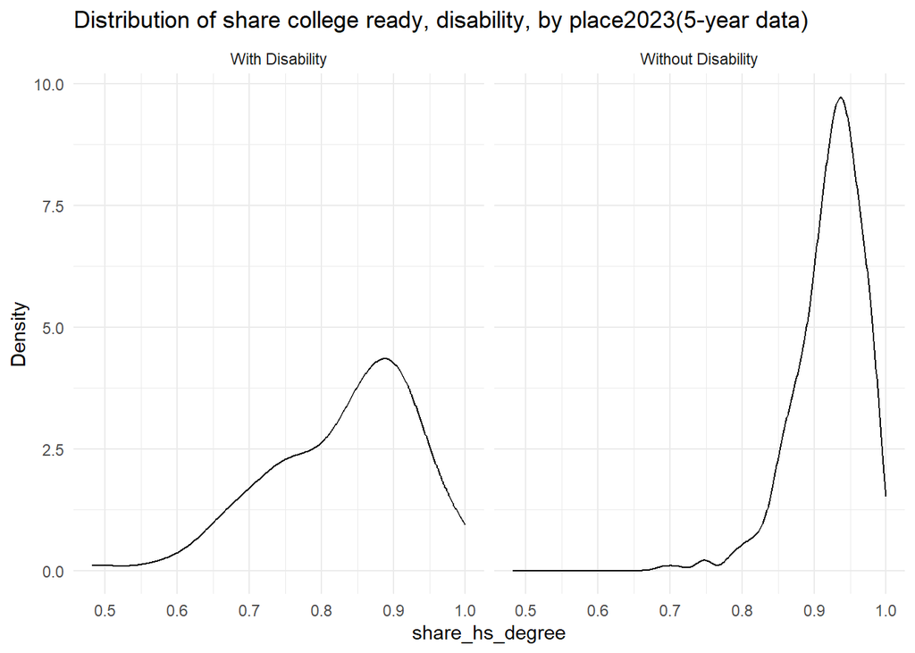

```r
metrics_education_sub %>%
  filter(year == params$year, subgroup_type == "disability") %>%
  ggplot(aes(x = share_hs_degree)) +
  geom_density(alpha = 0.15) +
  facet_wrap(~subgroup) +
  labs(
    title = paste0("Distribution of share college ready, disability, by place", params$year, "(5-year data)"),
    y = "Density"
  ) +
  theme_minimal()
```

### Time trends

Compare trends for the share college ready overtime for all years in the data.

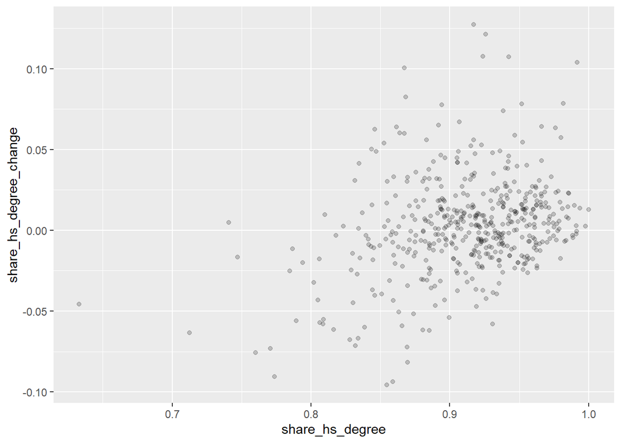

```r
metrics_education_all %>%
  group_by(geoid) %>%
  mutate(share_hs_degree_change = share_hs_degree - lag(share_hs_degree)) %>%
  filter(year == params$year) %>%
  ggplot(aes(share_hs_degree, share_hs_degree_change)) +
  geom_point(alpha = 0.2)
```

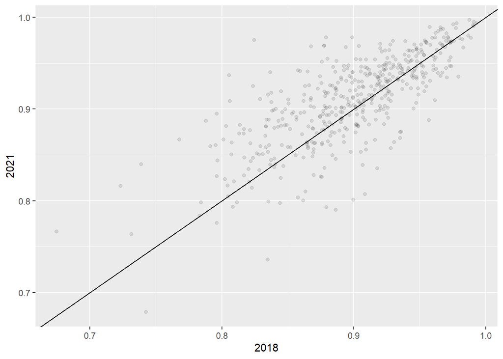

```r
metrics_education_all %>%
  select(year, geoid, share_hs_degree) %>%
  pivot_wider(
    names_from = year,
    values_from = share_hs_degree
  ) %>%
  ggplot(aes(`2018`, `2021`)) +
  geom_abline() +
  geom_point(alpha = 0.1)
```

### Confidence intervals

Check the missingness pattern for confidence intervals.

```r
nonmissing <- metrics_education_all |>
  filter(!is.na(share_hs_degree) & !is.na(share_hs_degree_lb) & !is.na(share_hs_degree_ub))
missing <- metrics_education_all |>
  filter(is.na(share_hs_degree) & is.na(share_hs_degree_lb) & is.na(share_hs_degree_ub))
stopifnot(nrow(nonmissing) + nrow(missing) == nrow(metrics_education_all))
```

Check the order. There are three variables and we are interested in pairwise comparisons, we can test that these line up. The upper-bound value should always be greater than the value and the lower-bound value. The value should always be greater than the lower-bound value.

```r
# upper bound is always greater than the estimate
stopifnot(all(nonmissing$share_hs_degree_ub >= nonmissing$share_hs_degree))
# upper bound is always greater than the lower bound
stopifnot(all(nonmissing$share_hs_degree_ub >= nonmissing$share_hs_degree_lb))
# estimate is always greater than the lower bound
stopifnot(all(nonmissing$share_hs_degree >= nonmissing$share_hs_degree_lb))
```

Look at confidence intervals.

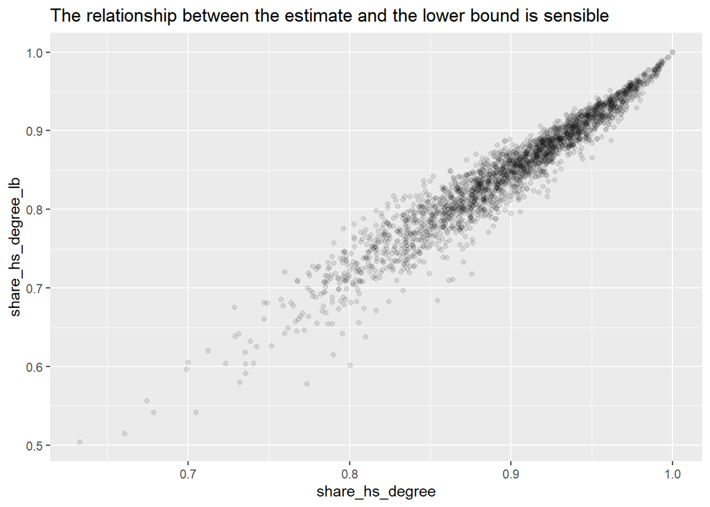

```r
metrics_education_all %>%
  ggplot(aes(share_hs_degree, share_hs_degree_lb)) +
  geom_point(alpha = 0.1) +
  labs(title = "The relationship between the estimate and the lower bound is sensible")
```

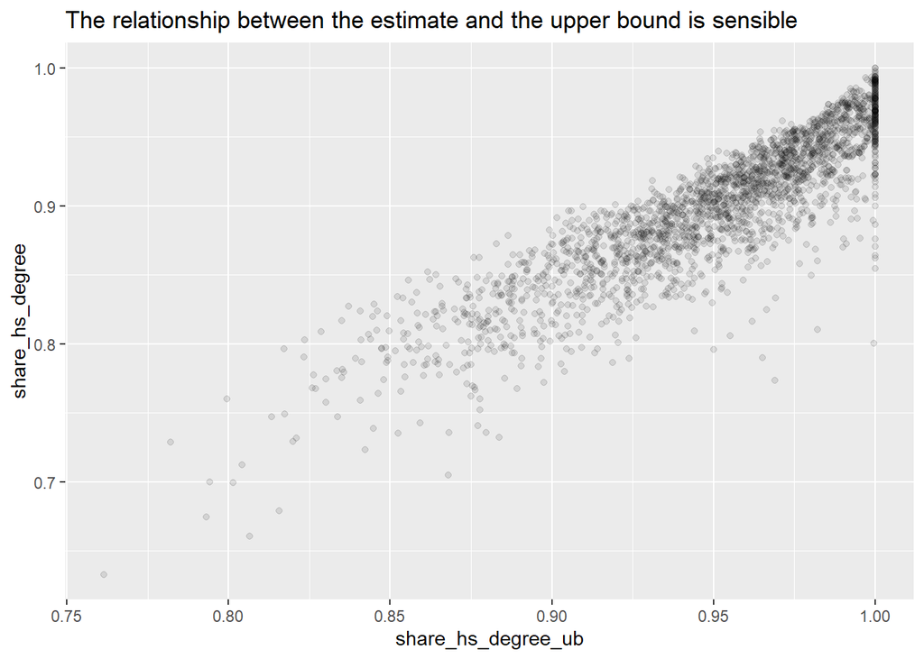

```r
metrics_education_all %>%
  ggplot(aes(share_hs_degree_ub, share_hs_degree)) +
  geom_point(alpha = 0.1) +
  labs(title = "The relationship between the estimate and the upper bound is sensible")
```

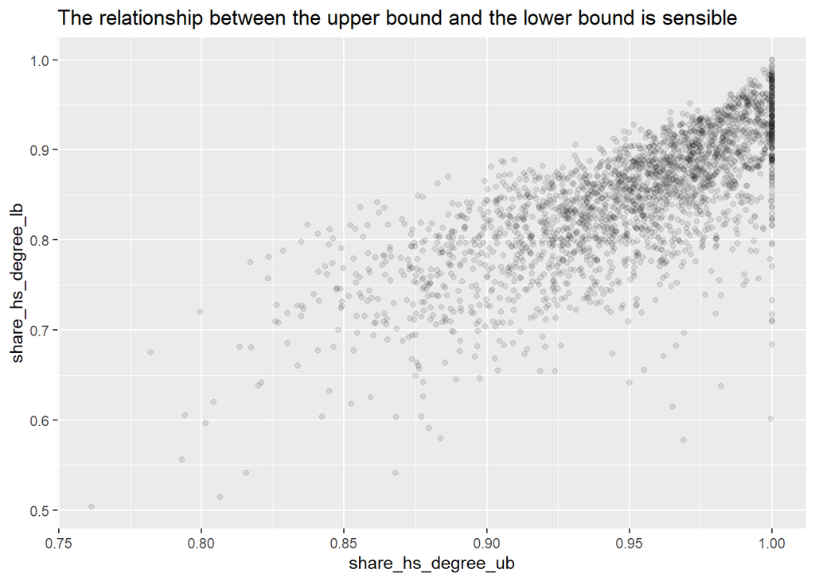

```r
metrics_education_all %>%
  ggplot(aes(share_hs_degree_ub, share_hs_degree_lb)) +
  geom_point(alpha = 0.1) +
  labs(title = "The relationship between the upper bound and the lower bound is sensible")
```

Distribution of confidence interval widths.

```r
metrics_education_all %>%
  mutate(ci_width = share_hs_degree_ub - share_hs_degree_lb) %>%
  pull(ci_width) %>%
  summary(na.rm = TRUE)
```

```
   Min. 1st Qu.  Median    Mean 3rd Qu.    Max.    NA's
0.00000 0.06622 0.09467 0.10211 0.12870 0.39853      21
```

### Quality and suppression

Look at the counts of the quality flag.

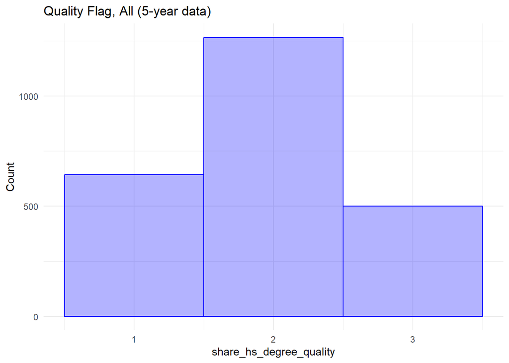

```r
metrics_education_all %>%
  select(share_hs_degree_quality) %>%
  ggplot(aes(x = share_hs_degree_quality)) +
  geom_histogram(color = "blue", fill = alpha("blue", 0.3), binwidth = 1.0) +
  theme_minimal() +
  ggtitle("Quality Flag, All (5-year data)") +
  ylab("Count")
```

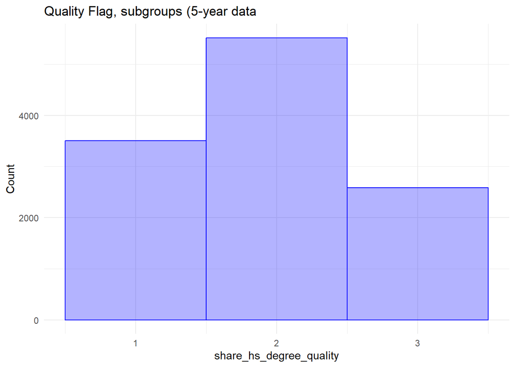

```r
metrics_education_sub %>%
  filter(subgroup != "All") %>%
  select(share_hs_degree_quality) %>%
  ggplot(aes(x = share_hs_degree_quality)) +
  geom_histogram(color = "blue", fill = alpha("blue", 0.3), binwidth = 1.0) +
  theme_minimal() +
  ggtitle("Quality Flag, subgroups (5-year data") +
  ylab("Count")
```

Look at quality by each individual subgroup.

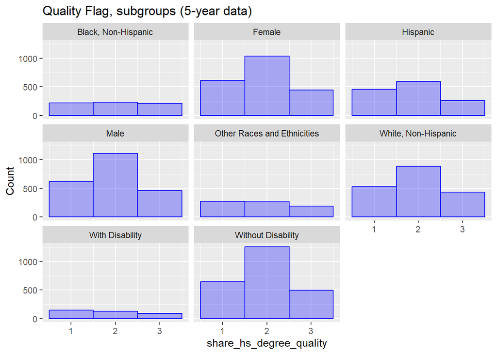

```r
metrics_education_sub %>%
  filter(subgroup != "All") %>%
  ggplot(aes(x = share_hs_degree_quality)) +
  geom_histogram(color = "blue", fill = alpha("blue", 0.3), binwidth = 1.0) +
  facet_wrap(~subgroup) +
  ggtitle("Quality Flag, subgroups (5-year data)") +
  ylab("Count")
```

Tabulate share of data suppressed by year.

```r
metrics_education_all %>%
  group_by(year) %>%
  summarise(suppressed = sum(is.na(share_hs_degree)),
            total = n(),
            suppressed_share = suppressed/total)
```

```
# A tibble: 5 x 4
   year suppressed total suppressed_share
  <dbl>      <int> <int>            <dbl>
1  2014         12   486          0.0247
2  2016          2   486          0.00412
3  2018          4   486          0.00823
4  2021          3   486          0.00617
5  2023          0   486          0
```

```r
metrics_education_sub %>%
  filter(subgroup != "All") %>%
  group_by(year, subgroup) %>%
  summarise(suppressed = sum(is.na(share_hs_degree)),
            total = n(),
            suppressed_share = suppressed/total)
```

```
# A tibble: 40 x 5
# Groups:   year [5]
    year subgroup                    suppressed total suppressed_share
   <dbl> <chr>                            <int> <int>            <dbl>
 1  2014 Black, Non-Hispanic                368   486           0.757
 2  2014 Female                             121   486           0.249
 3  2014 Hispanic                           281   486           0.578
 4  2014 Male                               100   486           0.206
 5  2014 Other Races and Ethnicities        391   486           0.805
 6  2014 White, Non-Hispanic                150   486           0.309
 7  2014 With Disability                    447   486           0.920
 8  2014 Without Disability                  18   486           0.0370
 9  2016 Black, Non-Hispanic                345   486           0.710
10  2016 Female                              51   486           0.105
# i 30 more rows
```

## Final Test and Export

Rename state.

```r
metrics_education_all_clean <- metrics_education_all %>%
  rename("state" = "statefip")

metrics_education_sub_clean <- metrics_education_sub %>%
  rename("state" = "statefip")
```

Order the variables how we want.

```r
metrics_education_all_clean <- metrics_education_all_clean %>%
  select(year, state, place, share_hs_degree,
         share_hs_degree_lb, share_hs_degree_ub, share_hs_degree_quality)

metrics_education_sub_clean <- metrics_education_sub_clean %>%
  select(year, state, place, subgroup_type, subgroup, share_hs_degree,
         share_hs_degree_lb, share_hs_degree_ub, share_hs_degree_quality)
```

Run files through evaluate final data function.

Test all.

```r
evaluate_final_data(data = metrics_education_all_clean, exp_form_path = here::here("10a_final-evaluation", "evaluation_form_college_overall_place.csv"), geography = "place", subgroups = FALSE, confidence_intervals = TRUE)
```

```
[1] "This data passes all tests!"
```

Test race/ethnicity.

```r
metrics_education_race <- metrics_education_sub_clean %>%
  filter(subgroup_type %in% c("all", "race-ethnicity")) %>%
  arrange(year, state, place, subgroup_type, subgroup)

evaluate_final_data(data = metrics_education_race, exp_form_path = here::here("10a_final-evaluation", "evaluation_form_college_race_eth_county.csv"), geography = "place", subgroups = TRUE, confidence_intervals = TRUE)
```

```
[1] "This data passes all tests!"
```

Test gender.

```r
metrics_education_gender <- metrics_education_sub_clean %>%
  filter(subgroup_type %in% c("all", "gender")) %>%
  arrange(year, state, place, subgroup_type, subgroup)

evaluate_final_data(data = metrics_education_gender, exp_form_path = here::here("10a_final-evaluation", "evaluation_form_college_gender_county.csv"), geography = "place", subgroups = TRUE, confidence_intervals = TRUE)
```

```
[1] "This data passes all tests!"
```

Test disability.

```r
metrics_education_disability <- metrics_education_sub_clean %>%
  filter(subgroup_type %in% c("all", "disability")) %>%
  arrange(year, state, place, subgroup_type, subgroup)

evaluate_final_data(data = metrics_education_disability, exp_form_path = here::here("10a_final-evaluation", "evaluation_form_college_disability_county.csv"), geography = "place", subgroups = TRUE, confidence_intervals = TRUE)
```

```
[1] "This data passes all tests!"
```

### Export

Export as CSVs.

```r
write_csv(metrics_education_all_clean, here::here("08_education", "data", "final", "metrics_college_place_all_longitudinal.csv"))

write_csv(metrics_education_race, here::here("08_education", "data", "final", "metrics_college_place_race-ethnicity_longitudinal.csv"))

write_csv(metrics_education_gender, here::here("08_education", "data", "final", "metrics_college_place_gender_longitudinal.csv"))


write_csv(metrics_education_disability, here::here("08_education", "data", "final", "metrics_college_place_disability_longitudinal.csv"))
```